# LDA - Delivery

Oscar Cabanelas

2023-03-23

- Data description (using plots and so on)
- Summary statistics (summary and so on)
- Fit multivariate model
- Two stage analysis
- random effect model (from wang)

```r
#install.packages("pacman")
library(pacman)
```

```r
p_load(readxl, magrittr, dplyr, lattice, ggplot2, nlme)
```

# Theory of Linear Mixed Effects Model(LMM)

## Index description

Let us assume that a given input data set $X$ has a dimension $N \times p$, with $N$ observations and $p$ predictors.

For each subject indexed with $i, i = 1,\cdots,I$, we can build a linear mixed effect model

$$\bf{Y}_i = \bf{X}_i \bf{\beta} +
\bf{Z}_i \bf{b}_i + \bf{\epsilon}_i$$

## The application of LMM

Linear Mixed Effects Model is used to analyse a data set, where the observations are not fully independent, while the top level clusters are assumed independent. Inside each cluster, the observations are correlated

## Introduction

The dataset contains information on patients who received a renal graft (kidney transplant).

The patients have been followed for at most 10 years.

The variables included in the analysis are: ID: identification number MALE: 0=female, 1=male AGE: Age at transplantation CARDIO: has the patient experienced a cardio-vascular problem during the years preceding the transplantation? 0=no, 1=yes REJECT: has the patient shown symptoms of graft rejection during the first three months after the transplantation? 0=no, 1=yes Hc0: Haematocrit level at the moment of transplantation Hc06: Haematocrit level 6 months after transplantation Hc1, Hc2, …, HC10: Haematocrit level 1 year, 2 years, …, 10 years after transplantation

## Data description

First of all, we load the data that will be used for the analysis.

```r
library(readxl)
trenal <- read_excel("Trenal.XLS")
head(trenal)
```

```
## # A tibble: 6 x 21
##     HC0  HC06   HC1   HC2   HC3   HC4   HC5   HC6   HC7   HC8   HC9  HC10    id
##   <dbl> <dbl> <dbl> <dbl> <dbl> <dbl> <dbl> <dbl> <dbl> <dbl> <dbl> <dbl> <dbl>
## 1    26    41    42    44    44    45    43    42    39    NA    NA    NA     1
## 2    26    41    42    44    44    45    43    42    39    NA    NA    NA     1
## 3    26    41    42    44    44    45    43    42    39    NA    NA    NA     1
## 4    26    41    42    44    44    45    43    42    39    NA    NA    NA     1
## 5    26    41    42    44    44    45    43    42    39    NA    NA    NA     1
## 6    26    41    42    44    44    45    43    42    39    NA    NA    NA     1
## # ... with 8 more variables: age <dbl>, male <dbl>, cardio <dbl>, reject <dbl>,
## #   const <dbl>, j <dbl>, respons <dbl>, time <dbl>
```

```r
dim(trenal)
```

```
## [1] 13920    21
```

```r
head(trenal)
```

```
## # A tibble: 6 x 21
##     HC0  HC06   HC1   HC2   HC3   HC4   HC5   HC6   HC7   HC8   HC9  HC10    id
##   <dbl> <dbl> <dbl> <dbl> <dbl> <dbl> <dbl> <dbl> <dbl> <dbl> <dbl> <dbl> <dbl>
## 1    26    41    42    44    44    45    43    42    39    NA    NA    NA     1
## 2    26    41    42    44    44    45    43    42    39    NA    NA    NA     1
## 3    26    41    42    44    44    45    43    42    39    NA    NA    NA     1
## 4    26    41    42    44    44    45    43    42    39    NA    NA    NA     1
## 5    26    41    42    44    44    45    43    42    39    NA    NA    NA     1
## 6    26    41    42    44    44    45    43    42    39    NA    NA    NA     1
## # ... with 8 more variables: age <dbl>, male <dbl>, cardio <dbl>, reject <dbl>,
## #   const <dbl>, j <dbl>, respons <dbl>, time <dbl>
```

```r
trenal= trenal[,-18]
summary(trenal)
```

```
##       HC0             HC06            HC1             HC2            HC3
##  Min.   :14.00   Min.   :22.00   Min.   :20.00   Min.   :17.0   Min.   :20.00
##  1st Qu.:28.00   1st Qu.:35.00   1st Qu.:36.00   1st Qu.:36.0   1st Qu.:36.00
##  Median :32.00   Median :38.55   Median :39.00   Median :40.0   Median :39.00
##  Mean   :31.86   Mean   :38.83   Mean   :39.71   Mean   :39.7   Mean   :39.17
##  3rd Qu.:36.00   3rd Qu.:42.00   3rd Qu.:43.00   3rd Qu.:43.0   3rd Qu.:43.00
##  Max.   :60.00   Max.   :61.70   Max.   :63.00   Max.   :65.0   Max.   :60.00
##  NA's   :12                      NA's   :12      NA's   :1044   NA's   :2460
##       HC4             HC5             HC6             HC7
##  Min.   :23.00   Min.   :17.00   Min.   :20.00   Min.   :17.00
##  1st Qu.:35.00   1st Qu.:35.00   1st Qu.:36.00   1st Qu.:35.00
##  Median :39.00   Median :39.00   Median :39.00   Median :39.00
##  Mean   :39.16   Mean   :39.02   Mean   :39.11   Mean   :38.85
##  3rd Qu.:43.00   3rd Qu.:43.00   3rd Qu.:43.00   3rd Qu.:42.00
##  Max.   :55.00   Max.   :56.00   Max.   :55.00   Max.   :60.00
##  NA's   :3768    NA's   :5016    NA's   :6096    NA's   :7140
##       HC8             HC9             HC10             id
##  Min.   :23.00   Min.   :17.00   Min.   :24.10   Min.   :   1.0
##  1st Qu.:35.00   1st Qu.:35.00   1st Qu.:35.00   1st Qu.: 290.8
##  Median :38.05   Median :38.50   Median :38.00   Median : 580.5
##  Mean   :38.35   Mean   :38.57   Mean   :38.49   Mean   : 580.5
##  3rd Qu.:42.00   3rd Qu.:42.00   3rd Qu.:42.00   3rd Qu.: 870.2
##  Max.   :55.00   Max.   :55.00   Max.   :54.00   Max.   :1160.0
##  NA's   :8064    NA's   :8988    NA's   :9744
##       age             male            cardio           reject
##  Min.   :15.00   Min.   :0.0000   Min.   :0.0000   Min.   :0.0000
##  1st Qu.:36.00   1st Qu.:0.0000   1st Qu.:0.0000   1st Qu.:0.0000
##  Median :48.00   Median :1.0000   Median :0.0000   Median :0.0000
##  Mean   :46.43   Mean   :0.5741   Mean   :0.1784   Mean   :0.3164
##  3rd Qu.:57.00   3rd Qu.:1.0000   3rd Qu.:0.0000   3rd Qu.:1.0000
##  Max.   :76.00   Max.   :1.0000   Max.   :1.0000   Max.   :1.0000
##  NA's   :12
##        j            respons           time
##  Min.   : 1.00   Min.   :14.00   Min.   : 0.000
##  1st Qu.: 3.75   1st Qu.:34.00   1st Qu.: 1.750
##  Median : 6.50   Median :38.00   Median : 4.500
##  Mean   : 6.50   Mean   :38.24   Mean   : 4.625
##  3rd Qu.: 9.25   3rd Qu.:42.00   3rd Qu.: 7.250
##  Max.   :12.00   Max.   :65.00   Max.   :10.000
##                  NA's   :4362
```

From the 1st column to the 12th, the values appear to be the levels of Haematocrit at each period, information that appears also with the combination of variables time and response. So, we decide to use only the information from the 13th column on in order not to overlap information and use the **long format** of it.

```r
trenal.long = trenal[,13:20]
summary(trenal.long)
```

```
##        id              age             male            cardio
##  Min.   :   1.0   Min.   :15.00   Min.   :0.0000   Min.   :0.0000
##  1st Qu.: 290.8   1st Qu.:36.00   1st Qu.:0.0000   1st Qu.:0.0000
##  Median : 580.5   Median :48.00   Median :1.0000   Median :0.0000
##  Mean   : 580.5   Mean   :46.43   Mean   :0.5741   Mean   :0.1784
##  3rd Qu.: 870.2   3rd Qu.:57.00   3rd Qu.:1.0000   3rd Qu.:0.0000
##  Max.   :1160.0   Max.   :76.00   Max.   :1.0000   Max.   :1.0000
##                   NA's   :12
##      reject             j            respons           time
##  Min.   :0.0000   Min.   : 1.00   Min.   :14.00   Min.   : 0.000
##  1st Qu.:0.0000   1st Qu.: 3.75   1st Qu.:34.00   1st Qu.: 1.750
##  Median :0.0000   Median : 6.50   Median :38.00   Median : 4.500
##  Mean   :0.3164   Mean   : 6.50   Mean   :38.24   Mean   : 4.625
##  3rd Qu.:1.0000   3rd Qu.: 9.25   3rd Qu.:42.00   3rd Qu.: 7.250
##  Max.   :1.0000   Max.   :12.00   Max.   :65.00   Max.   :10.000
##                                   NA's   :4362
```

Now, it is interesting to rellocate the variables in order to have a clear format . Moreover, some of the variables are transformed to factor since they are not numerical ones.

```r
trenal.long$id = as.factor(trenal.long$id)
trenal.long$j = as.factor(trenal.long$j)
trenal.long$male = as.factor(trenal.long$male)
trenal.long$cardio = as.factor(trenal.long$cardio)
trenal.long$reject = as.factor(trenal.long$reject)

data <- trenal.long %>%
relocate(id) %>%
relocate(j,.after=id)%>%
relocate(time,.after = j)%>%
relocate(respons,.after=time)
summary(data)
```

```
##        id              j             time           respons
##  1      :   12   1      :1160   Min.   : 0.000   Min.   :14.00
##  2      :   12   2      :1160   1st Qu.: 1.750   1st Qu.:34.00
##  3      :   12   3      :1160   Median : 4.500   Median :38.00
##  4      :   12   4      :1160   Mean   : 4.625   Mean   :38.24
##  5      :   12   5      :1160   3rd Qu.: 7.250   3rd Qu.:42.00
##  6      :   12   6      :1160   Max.   :10.000   Max.   :65.00
##  (Other):13848   (Other):6960                    NA's   :4362
##       age        male     cardio    reject
##  Min.   :15.00   0:5928   0:11436   0:9516
##  1st Qu.:36.00   1:7992   1: 2484   1:4404
##  Median :48.00
##  Mean   :46.43
##  3rd Qu.:57.00
##  Max.   :76.00
##  NA's   :12
```

Now, we can plot the data. To do that, we are going to create a spaguetti plot.

```r
Plot1<-xyplot(respons ~ time, groups = id,
              data = trenal.long,
              type = "l" ,xlab="Years after transplation",ylab="Levels of Haematocrit after transplation")
#add title
```

**Comment**:

To do that, we are going to use the ggplot function to make it beauty.

```r
set.seed(1)
selected <- sample(1:length(unique(trenal.long$id)),100,replace=T)
data.selected = trenal.long[(trenal.long$id %in% c(selected)), ]
```

Plot again

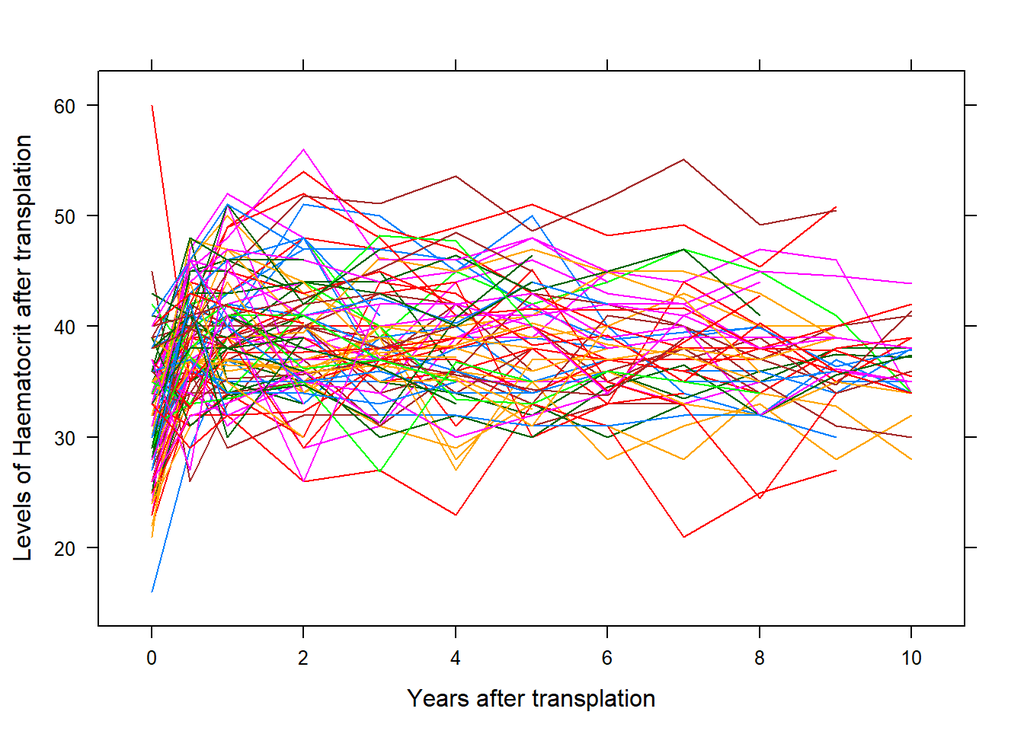

```r
(Plot2<-xyplot(respons ~ time, groups = id,
              data = data.selected,
              type = "l" ,xlab="Years after transplation",ylab="Levels of Haematocrit after transplation"))
```

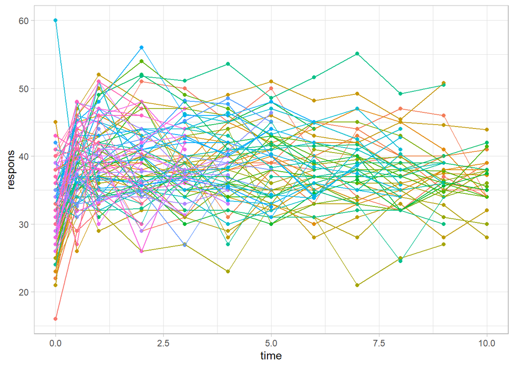

```r
ggplot(data.selected,aes(x=time,y=respons,group=id,color=id))+geom_point()+ geom_line()+theme_light()+ theme(legend.position = "none")
```

After choosing a random sample, we can see that the first year after the treatment there is a peak in the level of Haematocrtit and, afterwards, it seems to stabilize in each of the sample individuals regardless their initial level.

Now, it is interesting to check if we can find differences between genders:

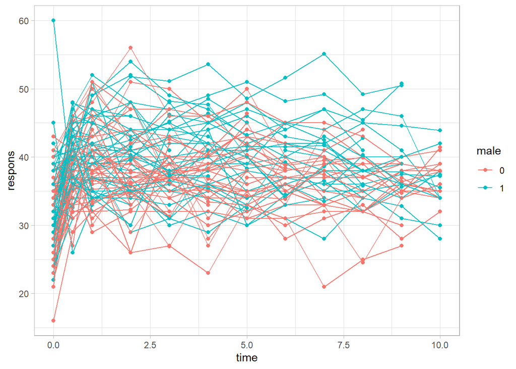

```r
ggplot(data.selected,aes(x=time,y=respons,group=id,color=male))+geom_point()+ geom_line()+theme_light()
```

Furthermore, we can check it depending on the level of cardio

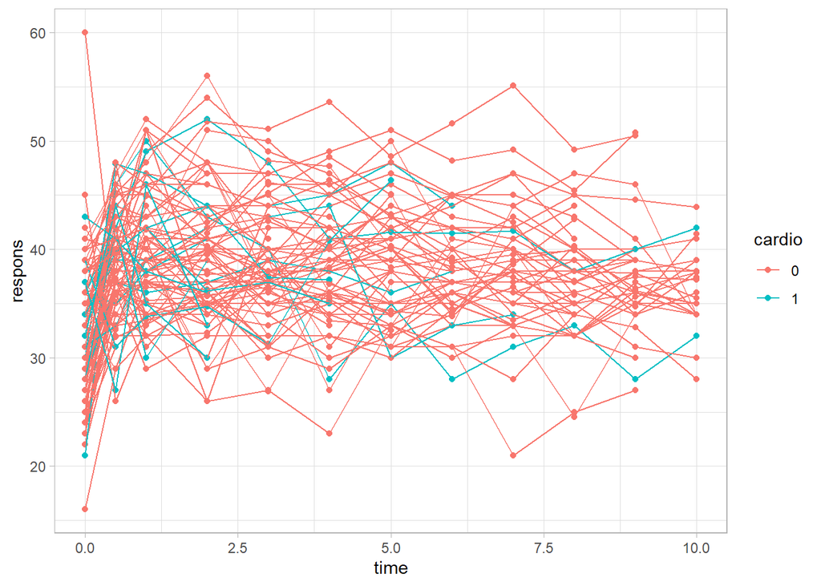

```r
ggplot(data.selected,aes(x=time,y=respons,group=id,color=cardio))+geom_point()+ geom_line()+theme_light()
```

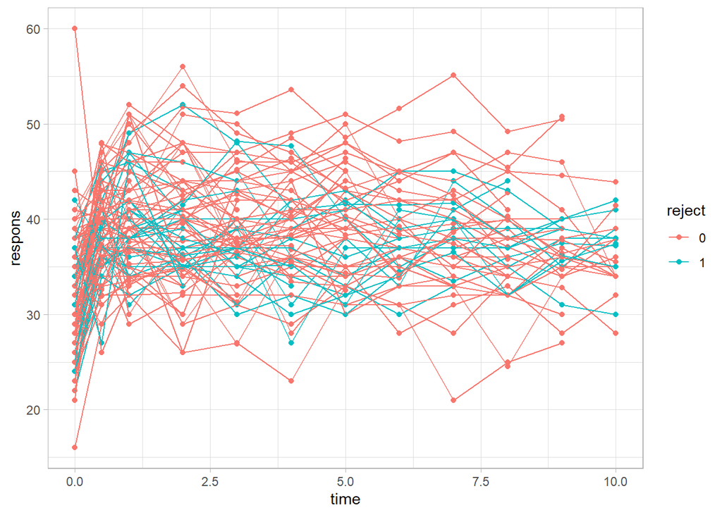

```r
ggplot(data.selected,aes(x=time,y=respons,group=id,color=reject))+geom_point()+ geom_line()+theme_light()
```

2. Summary statistics …

Analysis of endpoints: the response at the last mesure

To check this, we need to extract the last measurement for each individual. To do that, we just need to select the row in which the time is equal to 10.0.

```r
last_measurement <- subset(trenal.long, trenal.long$time == 10)
summary(last_measurement)
```

```
##        id            age        male    cardio  reject        j
##  1      :   1   Min.   :15.00   0:494   0:953   0:793   12     :1160
##  2      :   1   1st Qu.:36.00   1:666   1:207   1:367   1      :   0
##  3      :   1   Median :48.00                           2      :   0
##  4      :   1   Mean   :46.43                           3      :   0
##  5      :   1   3rd Qu.:57.00                           4      :   0
##  6      :   1   Max.   :76.00                           5      :   0
##  (Other):1154   NA's   :1                               (Other):   0
##     respons           time
##  Min.   :24.10   Min.   :10
##  1st Qu.:35.00   1st Qu.:10
##  Median :38.00   Median :10
##  Mean   :38.49   Mean   :10
##  3rd Qu.:42.00   3rd Qu.:10
##  Max.   :54.00   Max.   :10
##  NA's   :812
```

```r
#Check the mean and everything about last point response
```

**Comment**

```r
last_measurement$resp_na<-ifelse(is.na(last_measurement$respons) == T, 1, 0)

last_measurement$resp_na<- as.factor(last_measurement$resp_na)
summary(last_measurement$resp_na)
```

```
##   0   1
## 348 812
```

How it is composed for male/female?

```r
last_measurement_male <- last_measurement %>%
  group_by(male) %>%
count(respons)
```

Analysis of increments: Difference between the response at the first available and the last one.

We will use just the non NA values

```r
trenal.long_no_na <- na.omit(trenal.long)
trenal.long.incr<-trenal.long_no_na %>%
  filter(time == c(0, 10)) %>%
  group_by(id) %>%
  mutate(incr = max(respons) - min (respons), one = 1) %>%
  filter(!incr %in% 0)
```

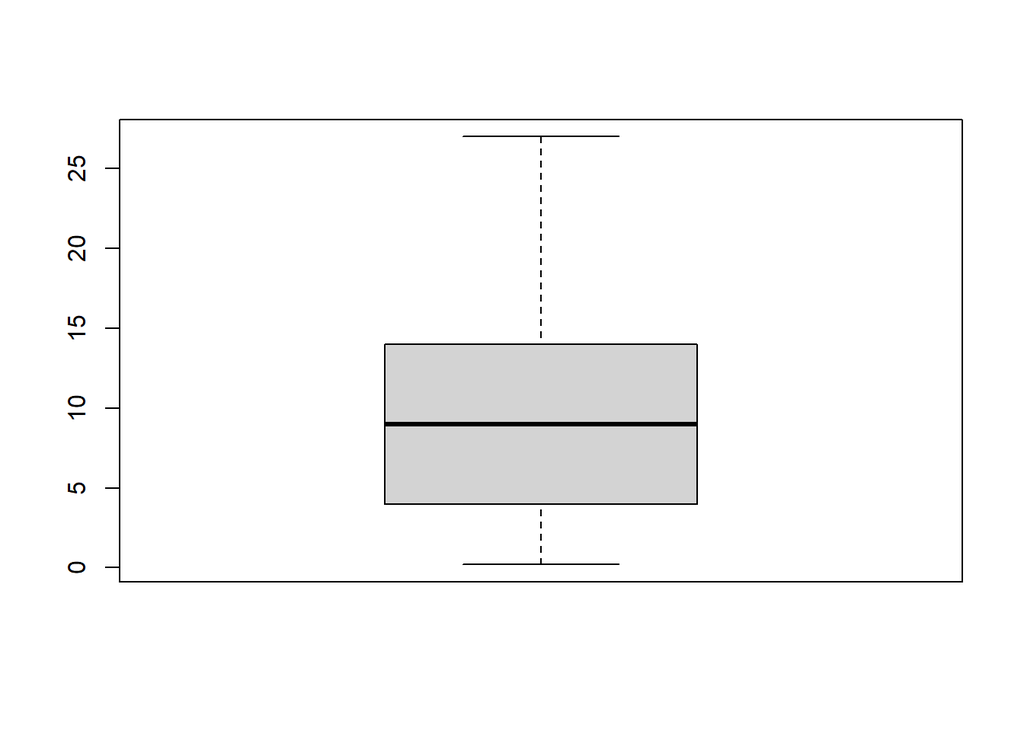

```r
boxplot(trenal.long.incr$incr)
```

Increment

3. Fit a multivariate model and find the most parsimonious mean structure which can be used to describe the average evolutions in the data. What covariance structures are applicable in this case? What is the most parsimonious structure you can find?

To do that, we are going to use the lm function. We will try to create different linear models using all the available variables in the data set.

On top of that, we want to test if the level of rejection affection in the response variable can depend on the time. Since that, we also apply one interaction between the time and the rejection level.

```r
trenal.lm<-lm(respons ~ time, data = trenal.long)
trenal.lm2 <- lm(respons ~ time + male, data = trenal.long)
trenal.lm3 <- lm(respons ~ time + male + reject, data = trenal.long)
trenal.lm4 <- lm(respons ~ time + male + cardio, data = trenal.long)
trenal.lm5 <- lm(respons ~ time + male + reject + cardio, data = trenal.long)
trenal.lm6 <- lm(respons ~ time + male + reject + reject:time, data = trenal.long)

anova(trenal.lm, trenal.lm2, trenal.lm3, trenal.lm4, trenal.lm5, trenal.lm6)
```

```
## Analysis of Variance Table
##
## Model 1: respons ~ time
## Model 2: respons ~ time + male
## Model 3: respons ~ time + male + reject
## Model 4: respons ~ time + male + cardio
## Model 5: respons ~ time + male + reject + cardio
## Model 6: respons ~ time + male + reject + reject:time
##   Res.Df    RSS Df Sum of Sq       F    Pr(>F)
## 1   9556 346639
## 2   9555 332478  1   14161.5 407.995 < 2.2e-16 ***
## 3   9554 331631  1     846.7  24.394 7.985e-07 ***
## 4   9554 332426  0    -794.7
## 5   9553 331584  1     841.9  24.255 8.580e-07 ***
## 6   9553 331630  0     -46.6
## ---
## Signif. codes:  0 '***' 0.001 '**' 0.01 '*' 0.05 '.' 0.1 ' ' 1
```

```r
anova(trenal.lm3, trenal.lm5)
```

```
## Analysis of Variance Table
##
## Model 1: respons ~ time + male + reject
## Model 2: respons ~ time + male + reject + cardio
##   Res.Df    RSS Df Sum of Sq      F Pr(>F)
## 1   9554 331631
## 2   9553 331584  1    47.183 1.3594 0.2437
```

CORR AND COVARIANCE STRUCTURE

```r
trenal.wide = trenal[,1:17]

dataCorr<- trenal.wide[, c(1:12)]
cor(dataCorr,use="complete.obs") #Also COV for covarianza
```

```
##             HC0      HC06       HC1       HC2       HC3       HC4       HC5
## HC0  1.00000000 0.2264123 0.1587116 0.1724777 0.2139805 0.1732267 0.1557624
## HC06 0.22641235 1.0000000 0.7562367 0.6233688 0.5520591 0.5278499 0.5143061
## HC1  0.15871158 0.7562367 1.0000000 0.7315995 0.6656006 0.6119867 0.5873331
## HC2  0.17247771 0.6233688 0.7315995 1.0000000 0.7284046 0.6382434 0.5996189
## HC3  0.21398049 0.5520591 0.6656006 0.7284046 1.0000000 0.7733522 0.7016965
## HC4  0.17322666 0.5278499 0.6119867 0.6382434 0.7733522 1.0000000 0.7888249
## HC5  0.15576243 0.5143061 0.5873331 0.5996189 0.7016965 0.7888249 1.0000000
## HC6  0.13620085 0.4569881 0.5004036 0.4869519 0.5786122 0.6814132 0.7592203
## HC7  0.10156045 0.3936597 0.4541699 0.4724703 0.5402798 0.6466212 0.7067887
## HC8  0.08419757 0.3687935 0.4454882 0.4244221 0.5030428 0.6040136 0.6080051
## HC9  0.08859254 0.3711560 0.4254622 0.3971477 0.4303661 0.5461579 0.5713338
## HC10 0.09718506 0.4210917 0.4301937 0.4647890 0.4972001 0.5629570 0.5800544
##            HC6       HC7        HC8        HC9       HC10
## HC0  0.1362008 0.1015604 0.08419757 0.08859254 0.09718506
## HC06 0.4569881 0.3936597 0.36879347 0.37115604 0.42109175
## HC1  0.5004036 0.4541699 0.44548815 0.42546216 0.43019368
## HC2  0.4869519 0.4724703 0.42442213 0.39714773 0.46478897
## HC3  0.5786122 0.5402798 0.50304282 0.43036614 0.49720006
## HC4  0.6814132 0.6466212 0.60401365 0.54615793 0.56295695
## HC5  0.7592203 0.7067887 0.60800514 0.57133378 0.58005440
## HC6  1.0000000 0.7414970 0.67347761 0.62938253 0.60329422
## HC7  0.7414970 1.0000000 0.71838142 0.63933448 0.65646214
## HC8  0.6734776 0.7183814 1.00000000 0.70316750 0.68501304
## HC9  0.6293825 0.6393345 0.70316750 1.00000000 0.74259683
## HC10 0.6032942 0.6564621 0.68501304 0.74259683 1.00000000
```

```r
cov(dataCorr,use="complete.obs")
```

```
##            HC0      HC06       HC1       HC2      HC3       HC4       HC5
## HC0  39.066556  7.665218  5.774002  6.234614  7.07784  5.763345  4.971864
## HC06  7.665218 29.338892 23.842148 19.527246 15.82455 15.219122 14.226481
## HC1   5.774002 23.842148 33.879074 24.627098 20.50234 18.961168 17.458390
## HC2   6.234614 19.527246 24.627098 33.446305 22.29312 19.647973 17.709378
## HC3   7.077840 15.824553 20.502342 22.293116 28.00580 21.785056 18.963882
## HC4   5.763345 15.219122 18.961168 19.647973 21.78506 28.334444 21.443314
## HC5   4.971864 14.226481 17.458390 17.709378 18.96388 21.443314 26.080017
## HC6   4.301388 12.506996 14.716768 14.229393 15.47169 18.327116 19.590611
## HC7   3.308261 11.112594 13.777065 14.240366 14.90100 17.938242 18.811183
## HC8   2.627503  9.973469 12.946223 12.254999 13.29138 16.052596 15.502522
## HC9   2.877108 10.445636 12.867175 11.933907 11.83365 15.105395 15.160039
## HC10  3.182038 11.948183 13.116956 14.080989 13.78347 15.697692 15.517650
##            HC6       HC7       HC8       HC9      HC10
## HC0   4.301388  3.308261  2.627503  2.877108  3.182038
## HC06 12.506996 11.112594  9.973469 10.445636 11.948183
## HC1  14.716768 13.777065 12.946223 12.867175 13.116956
## HC2  14.229393 14.240366 12.254999 11.933907 14.080989
## HC3  15.471694 14.900997 13.291382 11.833646 13.783466
## HC4  18.327116 17.938242 16.052596 15.105395 15.697692
## HC5  19.590611 18.811183 15.502522 15.160039 15.517650
## HC6  25.530100 19.525773 16.989891 16.523324 15.968301
## HC7  19.525773 27.160964 18.692563 17.312397 17.921962
## HC8  16.989891 18.692563 24.927707 18.241328 17.916092
## HC9  16.523324 17.312397 18.241328 26.996843 20.212166
## HC10 15.968301 17.921962 17.916092 20.212166 27.441419
```

```r
library("PerformanceAnalytics")
```

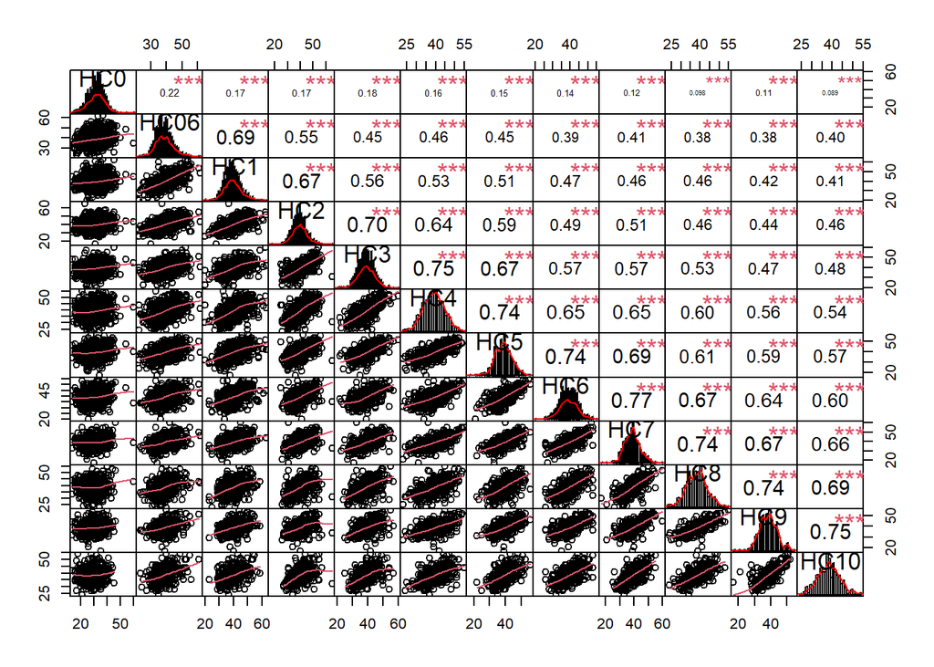

```r
chart.Correlation(dataCorr , histogram=T)
```

4. Use an explicit two-stage analysis to get an initial impression about trends and effects of covariates.

As a first step, we need to create a *groupedData* object in order to apply it to the following process.

```r
trenal_grouped1<-groupedData(respons~time|id,trenal.long_no_na, inner = ~ male, labels=list(y="level of Haematocrit"),units=list(y="level of Haematocrit "))


trenal_grouped2<-groupedData(respons~time|id,trenal.long_no_na, inner = ~ reject, labels=list(y="level of Haematocrit"),units=list(y="level of Haematocrit "))

trenal_grouped3<-groupedData(respons~time|id,trenal.long_no_na, inner = ~ cardio, labels=list(y="level of Haematocrit"),units=list(y="level of Haematocrit "))

#plot(trenal_grouped1, inner =  T, key = F)
#plot(trenal_grouped2, inner = T, key = F)
#plot(trenal_grouped3, inner = T, key = F)
#here, we do not declare any group, but I should group by male, reject or cardio
#outer: time dependent
#inner: not time dependent (male, )
```

first step: A model for each individual estimating the intercept and time was adjusted. It is not significant which of the three previous models we will use, since the info is the same.

```r
#REMOVE MISSINGS HERE

modlist1 <- lmList (respons ~ time, trenal_grouped1 , na.action = na.pass)


#plot(intervals(modlist1))
#plot(trenal_grouped)
```

**Comment** In here, he have the model with a beta for each individual.

Then, we can extract all the beta0 and beta1 obtained from the model. This will be used in the following steps

```r
#attributes(modlist1)


beta0<- coef(modlist1)[,1]

beta1<- coef(modlist1)[,2]
```

As we can see, huge part of the beta’s are missings since we did not remove the missigness of the data for this analysis.

```r
coef(modlist1)
```

```
##      (Intercept)          time
## 495     26.83333  3.000000e+00
## 865     22.95439  1.073684e+00
## 192     27.83333 -5.000000e+00
## 422     32.80000 -7.200000e+00
## 26      25.66667  6.000000e+00
## 214     23.57500  2.150000e+00
## 298     27.62551  2.070977e-01
## 326     28.95410 -3.625293e-01
## 421     31.20690 -6.206897e-01
## 428     28.73706  1.816262e-01
## 577     31.40000 -1.714286e-01
## 660     30.66667  2.000000e+00
## 762     31.52661 -6.610644e-01
## 848     31.89825 -9.894737e-01
```

[output cut: 1145 more lines]

```r
bbdd<-data.frame(id=as.numeric(attributes(modlist1)$names),
                 beta0=coef(modlist1)[,1],beta1=coef(modlist1)[,2])
bbdd <- merge(trenal.long, bbdd[,c("id","beta0", "beta1")], by.x = "id", all.x = T)

bbdd <- bbdd[order(bbdd[,1]),]
```

```r
#Boxplot
meanbeta0bymale<-tapply(bbdd$beta0,as.factor(bbdd$male),mean,na.rm=T)
meanbeta1bymale<-tapply(bbdd$beta1,as.factor(bbdd$male),mean,na.rm=T)

meanbeta0byreject<-tapply(bbdd$beta0,as.factor(bbdd$reject),mean,na.rm=T)
meanbeta1byreject<-tapply(bbdd$beta1,as.factor(bbdd$reject),mean,na.rm=T)

meanbeta0bycardio<-tapply(bbdd$beta0,as.factor(bbdd$cardio),mean,na.rm=T)
meanbeta1bycardio<-tapply(bbdd$beta1,as.factor(bbdd$cardio),mean,na.rm=T)


#Let's check if they are quite related ?inverse correlation?

with(bbdd,cor(beta0,beta1))
```

```
## [1] NA
```

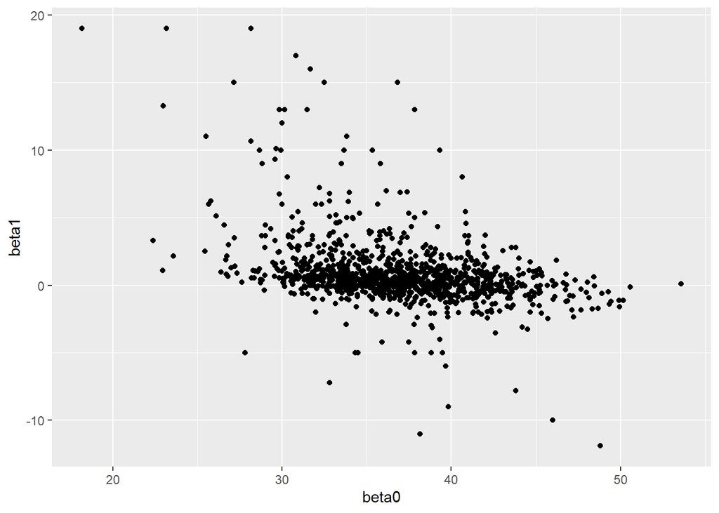

```r
library(ggplot2)
ggplot(bbdd, aes(x=beta0, y=beta1)) + geom_point()
```

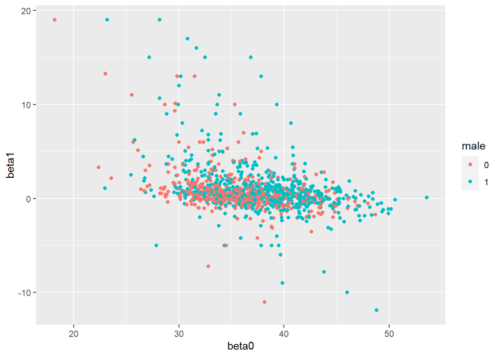

```r
ggplot(bbdd, aes(x=beta0, y=beta1, color=male)) + geom_point()
```

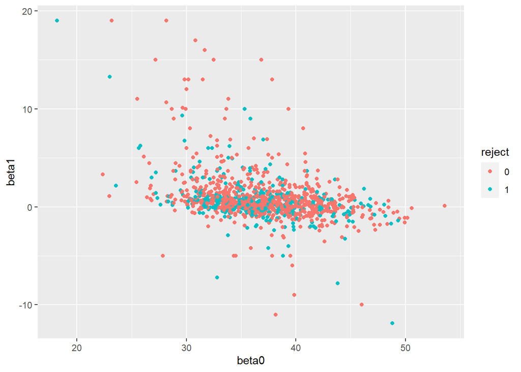

```r
ggplot(bbdd, aes(x=beta0, y=beta1, color=reject)) + geom_point()
```

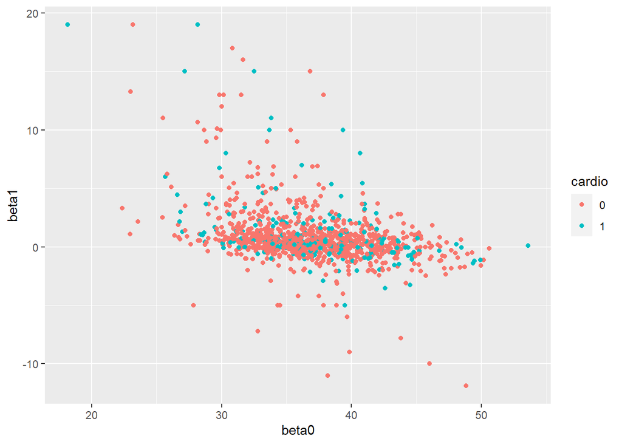

```r
ggplot(bbdd, aes(x=beta0, y=beta1, color=cardio)) + geom_point()
```

```r
#install.packages('dplyr', repos = 'https://cloud.r-project.org')

library(dplyr)
bbdd %>%
  group_by(male) %>%
  summarize(cor=cor(beta0, beta1))
```

```
## # A tibble: 2 x 2
##   male     cor
##   <fct>  <dbl>
## 1 0     -0.416
## 2 1     NA
```

```r
bbdd %>%
  group_by(cardio) %>%
  summarize(cor=cor(beta0, beta1))
```

```
## # A tibble: 2 x 2
##   cardio    cor
##   <fct>   <dbl>
## 1 0      NA
## 2 1      -0.448
```

```r
bbdd %>%
  group_by(reject) %>%
  summarize(cor=cor(beta0, beta1))
```

```
## # A tibble: 2 x 2
##   reject    cor
##   <fct>   <dbl>
## 1 0      -0.375
## 2 1      NA
```

2nd step:

```r
# Fit a model for the intercept
modbeta0<-lm(beta0~male+cardio,bbdd)
summary(modbeta0)
```

```
##
## Call:
## lm(formula = beta0 ~ male + cardio, data = bbdd)
##
## Residuals:
##      Min       1Q   Median       3Q      Max
## -17.7108  -3.1054  -0.0243   2.8390  15.5812
##
## Coefficients:
##             Estimate Std. Error t value Pr(>|t|)
## (Intercept) 35.58738    0.06081 585.234  < 2e-16 ***
## male1        2.11908    0.07712  27.478  < 2e-16 ***
## cardio1      0.29012    0.09957   2.914  0.00358 **
## ---
## Signif. codes:  0 '***' 0.001 '**' 0.01 '*' 0.05 '.' 0.1 ' ' 1
##
## Residual standard error: 4.497 on 13905 degrees of freedom
##   (12 observations deleted due to missingness)
## Multiple R-squared:  0.05227,    Adjusted R-squared:  0.05214
## F-statistic: 383.5 on 2 and 13905 DF,  p-value: < 2.2e-16
```

```r
confint(modbeta0)
```

```
##                   2.5 %    97.5 %
## (Intercept) 35.46818606 35.706573
## male1        1.96791843  2.270242
## cardio1      0.09495222  0.485292
```

```r
### Fit a model for the slope
# All the variables should be included
modbeta1<-lm(beta1~male+cardio,bbdd)
summary(modbeta1)
```

```
##
## Call:
## lm(formula = beta1 ~ male + cardio, data = bbdd)
##
## Residuals:
##      Min       1Q   Median       3Q      Max
## -12.7690  -1.0437  -0.3768   0.3724  18.1310
##
## Coefficients:
##             Estimate Std. Error t value Pr(>|t|)
## (Intercept)  0.69343    0.03483  19.908  < 2e-16 ***
## male1        0.17559    0.04417   3.975 7.07e-05 ***
## cardio1      0.41228    0.05703   7.229 5.13e-13 ***
## ---
## Signif. codes:  0 '***' 0.001 '**' 0.01 '*' 0.05 '.' 0.1 ' ' 1
##
## Residual standard error: 2.576 on 13905 degrees of freedom
##   (12 observations deleted due to missingness)
## Multiple R-squared:  0.004951,   Adjusted R-squared:  0.004808
## F-statistic: 34.59 on 2 and 13905 DF,  p-value: 1.031e-15
```

```r
confint(modbeta1)
```

```
##                  2.5 %    97.5 %
## (Intercept) 0.62516106 0.7617089
## male1       0.08900118 0.2621718
## cardio1     0.30048466 0.5240708
```

```r
#### END OF  EXERCISE
```

6. Pay attention to the missing, especially the ones presented by the outcome variable. Do your results still hold despite the missingness?

Outcome analysis

```r
summary(trenal.long$respons)
```

```
##    Min. 1st Qu.  Median    Mean 3rd Qu.    Max.    NA's
##   14.00   34.00   38.00   38.24   42.00   65.00    4362
```

From the 13920 measurements, 4362 are NA’s. That represents a 31% of the response measurements are NAs.

How are they distributed?

Male

```r
trenal.long.na<-trenal.long %>%
  filter(is.na(respons) == T)

trenal_na_male <- aggregate(trenal.long.na$respons, by=list(trenal.long.na$male), FUN=length)
trenal_na_male
```

```
##   Group.1    x
## 1       0 1715
## 2       1 2647
```

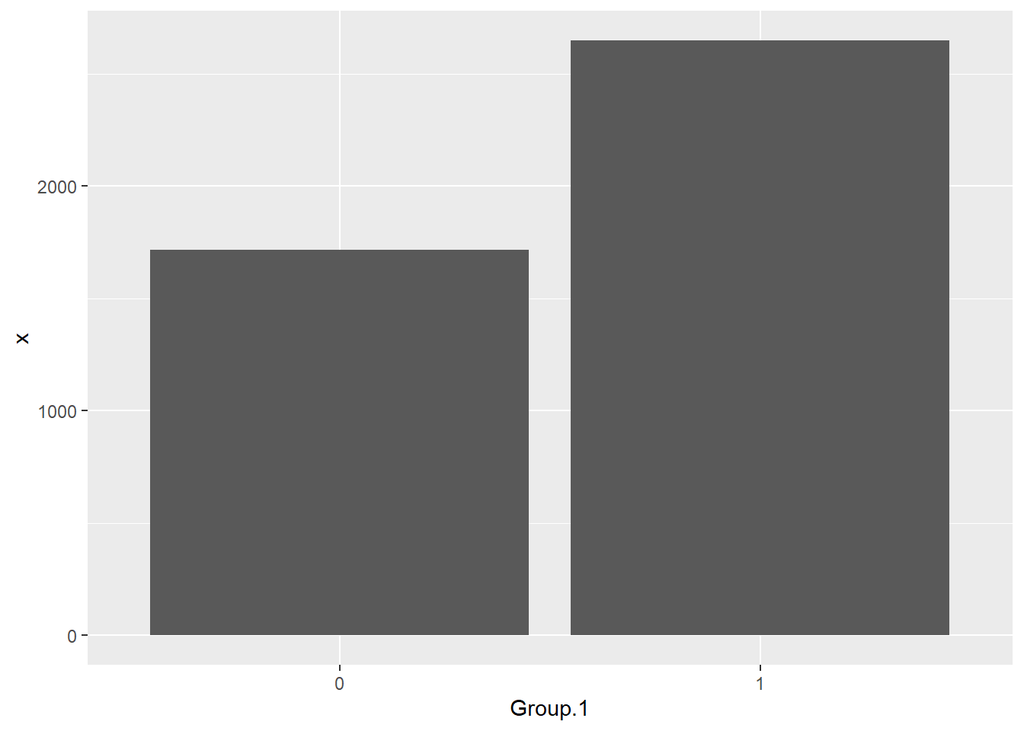

```r
p<-ggplot(data=trenal_na_male, aes(x=Group.1, y=x)) +
  geom_bar(stat="identity")
p
```

Reject

```r
trenal_na_reject <- aggregate(trenal.long.na$respons, by=list(trenal.long.na$reject), FUN=length)
trenal_na_reject
```

```
##   Group.1    x
## 1       0 3202
## 2       1 1160
```

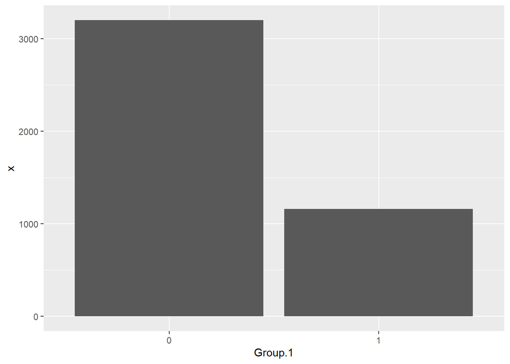

```r
p<-ggplot(data=trenal_na_reject, aes(x=Group.1, y=x)) +
  geom_bar(stat="identity")
p
```

Cardio

```r
trenal_na_cardio <- aggregate(trenal.long.na$respons, by=list(trenal.long.na$cardio), FUN=length)
trenal_na_cardio
```

```
##   Group.1    x
## 1       0 3502
## 2       1  860
```

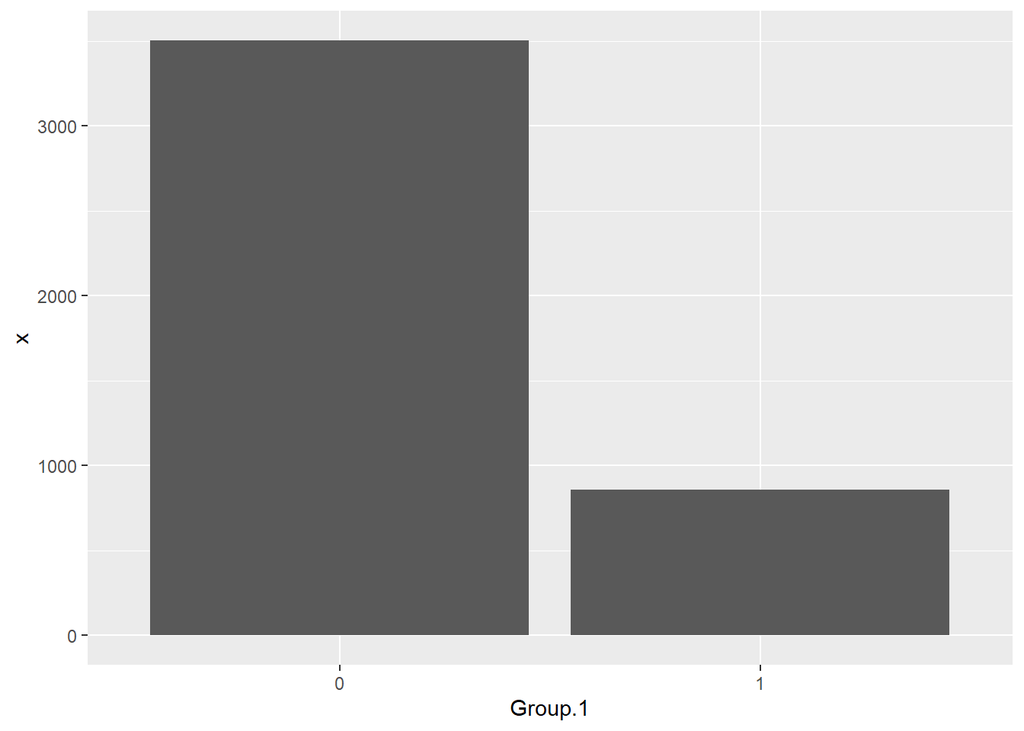

```r
p<-ggplot(data=trenal_na_cardio, aes(x=Group.1, y=x)) +
  geom_bar(stat="identity")
p
```